# Analytics in Practice - Assignment 2: Data Visualization

# 4. Which Airport has highest Arrival delay?

```r
Arrival_Delay <- FlightData  %>% filter(ArrDelay > 0)%>% select("Origin","OriginCityName") %>%
  group_by(OriginCityName) %>% summarise(Count=n())

Arrival_Delay
```

```
## # A tibble: 5 x 2
##   OriginCityName    Count
##   <fct>             <int>
## 1 Los Angeles, CA     753
## 2 Sacramento, CA      178
## 3 San Diego, CA       279
## 4 San Francisco, CA   567
## 5 San Jose, CA        148
```

# Answer

- Similar to the Departure delay, after data extraction we have found the total count of Flight arrival delay among all the California City Airports.
- Below graph represents the scale at which the Arrival Delay frequency is based on the Cities. Here, Los Angles have highest arrival delay and Lowest in San Jose.

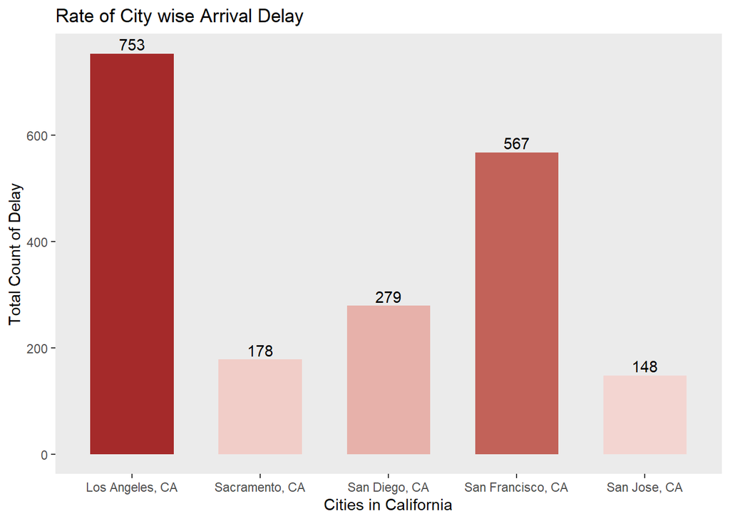

```r
ggplot(Arrival_Delay, aes(OriginCityName, Count)) +
  geom_col(aes(fill = Count), width = 0.65) +
  scale_fill_gradient2(low="white", high="brown") +
  geom_text(aes(OriginCityName, Count, label = Count), vjust = -0.3) +
  theme(legend.position = "none", panel.grid.major = element_blank(), panel.grid.minor = element_blank()) +
  labs(title = "Rate of City wise Arrival Delay",  x = "Cities in California",  y ="Total Count of Delay")
```

# 5. How do you relate the delay pattern to the distance travelled?

```r
DelayByDistance <- FlightData %>% select("DistanceGroup","DepDelay","ArrDelay") %>%
  gather("Delay_Type","Delay_Time", -1)%>% group_by(DistanceGroup,Delay_Type)%>% filter(Delay_Time > 0) %>%
  group_by(DistanceGroup,Delay_Type) %>% summarise(Frequency = n())

head(DelayByDistance)
```

```
## # A tibble: 6 x 3
## # Groups:   DistanceGroup [3]
##   DistanceGroup Delay_Type Frequency
##           <int> <chr>          <int>
## 1             1 ArrDelay         319
## 2             1 DepDelay         293
## 3             2 ArrDelay         338
## 4             2 DepDelay         394
## 5             3 ArrDelay         342
## 6             3 DepDelay         380
```

# Answer

- We have gathered the group of distances travelled by the Flights and the filtered them based on the Traffic delay for both Arrival and departure flights to know the frequency of flight delay at certain distance.
- The below graph displays the Distance to type of Flight delay in Miles.
- RED line graph displays the Arrival delay pattern based on distance whereas BLUE plot displays the departure delay.
- The DARK BLUE line shows the pattern of how exactly the flight delay is affected based on the distance travelled.
- Thus looking at the plot we can conclude that the flights with nearby locations are facing highers delays and as the distance increases the delay in flight become lesser and lesser in an approximation.
- The highest delay is over the 250 to 750 miles.

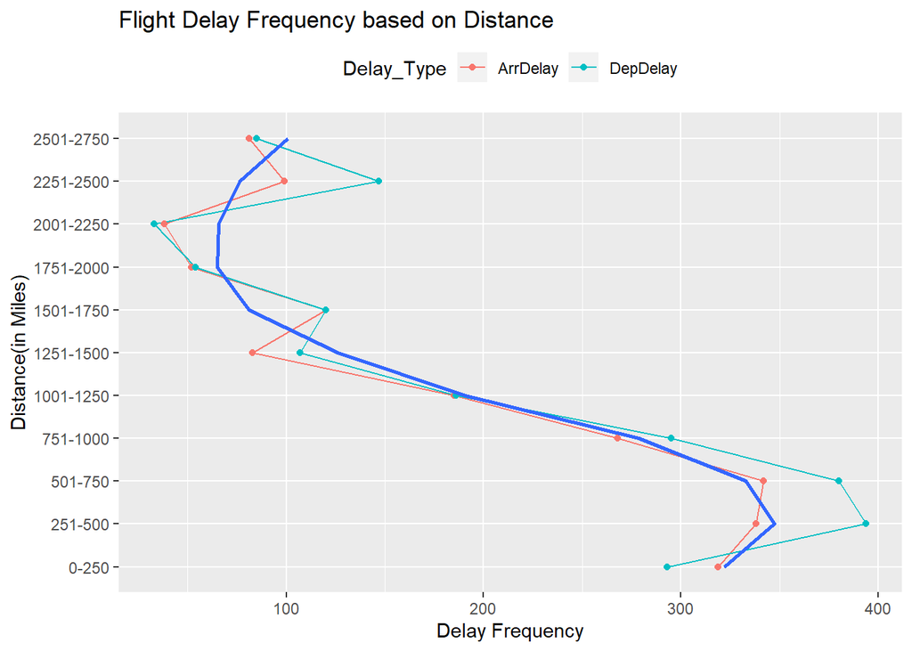

```r
ggplot(DelayByDistance, aes(DistanceGroup, Frequency)) +
  geom_line(aes(color = Delay_Type)) + geom_point(aes(color = Delay_Type)) +
  labs(title = "Flight Delay Frequency based on Distance",  x = "Distance(in Miles)",  y ="Delay Frequency") +
  geom_smooth(method = "loess", se = FALSE, size = 1) + theme(legend.position="top") +
  scale_x_discrete(limit=c(1:11), labels=c("0-250", "251-500", "501-750", "751-1000", "1001-1250", "1251-1500", "1501-1750", "1751-2000", "2001-2250", "2251-2500","2501-2750")) +
  coord_flip()
```

# 6. Is there any correlation between weather delay and carrier delay?

```r
DataWC <- na.omit(cbind.data.frame(Weather = round(FlightData$WeatherDelay/60), Carrier = round(FlightData$CarrierDelay/60)))
summary(DataWC)
```

```
##     Weather            Carrier
##  Min.   : 0.00000   Min.   : 0.0000
##  1st Qu.: 0.00000   1st Qu.: 0.0000
##  Median : 0.00000   Median : 0.0000
##  Mean   : 0.07285   Mean   : 0.3254
##  3rd Qu.: 0.00000   3rd Qu.: 0.0000
##  Max.   :14.00000   Max.   :13.0000
```

```r
Correlation <- cor(DataWC)
Correlation
```

```
##            Weather    Carrier
## Weather  1.0000000 -0.0315184
## Carrier -0.0315184  1.0000000
```

# Answer

- Looking at the raw data it is very difficult to extract any information. Hence we have altered the data by changing the time frame from minutes to hours.
- Also I have computed the correlation value between the Carrier Delay and Weather Delay, which is -0.0315184 i.e. they are negatively correlated.
- Thus by looking at the graph we could see the the the carrier delay and the weather delay gives a right angle graph and doesn’t give much information.

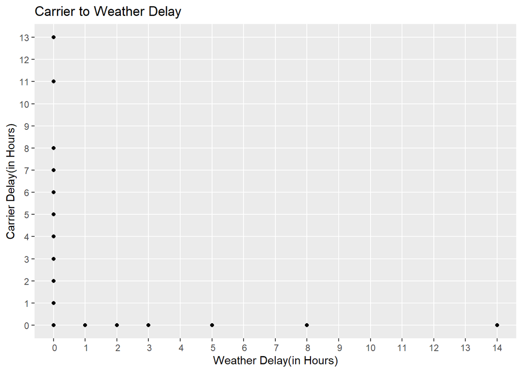

```r
ggplot(DataWC, aes(Weather, Carrier)) + geom_point() + scale_x_discrete(limit=c(0:14))+ scale_y_discrete(limit=c(0:13)) +
  labs(title = "Carrier to Weather Delay", x = "Weather Delay(in Hours)",  y ="Carrier Delay(in Hours)")
```

- Also by calculatinng the correlation value of the data, below correlation plot is drawn.

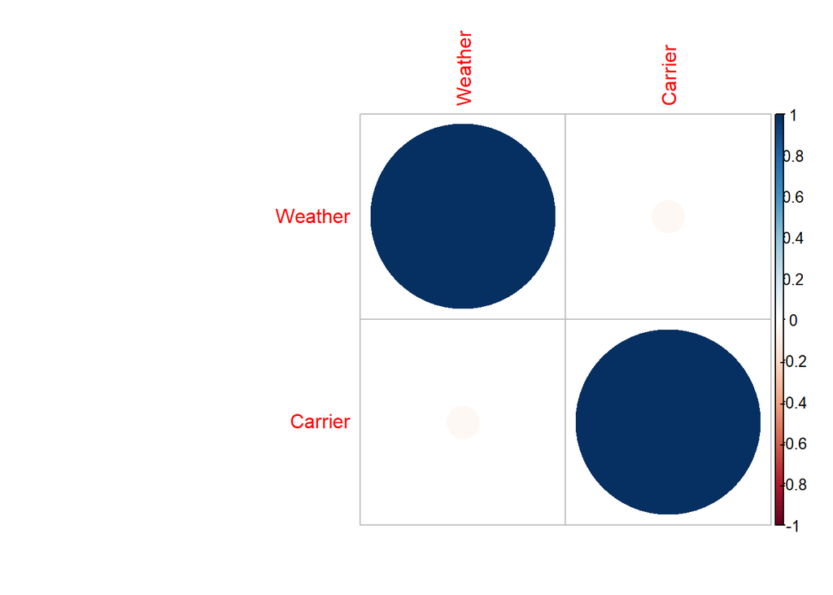

```r
corrplot::corrplot(Correlation)
```

# 7. What is the delay pattern you can find in respective states?

```r
DelayPatterns <- FlightData %>% select("OriginCityName","ArrDelay","DepDelay","CarrierDelay","WeatherDelay") %>%
  gather("Delay_Type","Delay_Time",-1) %>% filter(Delay_Time > 0) %>%
  group_by(OriginCityName,Delay_Type)  %>% summarise(Frequency=n())

head(DelayPatterns)
```

```
## # A tibble: 6 x 3
## # Groups:   OriginCityName [2]
##   OriginCityName  Delay_Type   Frequency
##   <fct>           <chr>            <int>
## 1 Los Angeles, CA ArrDelay           753
## 2 Los Angeles, CA CarrierDelay       182
## 3 Los Angeles, CA DepDelay           811
## 4 Los Angeles, CA WeatherDelay        36
## 5 Sacramento, CA  ArrDelay           178
## 6 Sacramento, CA  CarrierDelay        53
```

# Answer

- To extract delay patterns we have computed the delay frequency in each city of California state based on the delay types.
- Above is a glimps of the data that is extracted.
- Thus, looking at the result below graph is computed having a grid of 4 parts each having a delay pattern of eachh city based on the type of delay.
- Hence we see the major delay is occured due to the Departure delay and in the city of Los Angeles.

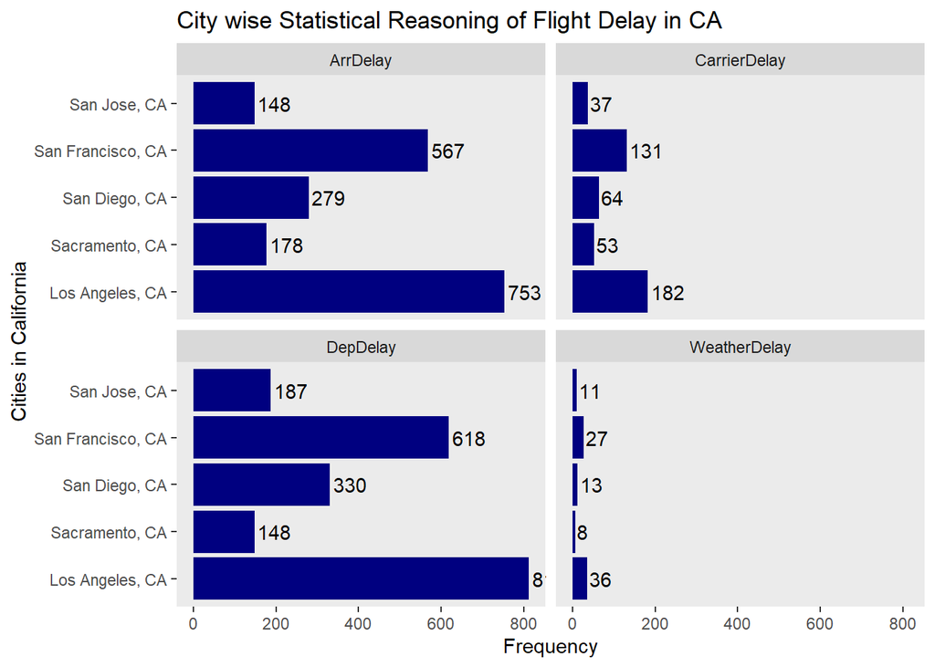

```r
ggplot(DelayPatterns, aes(OriginCityName, Frequency)) +
  geom_bar(stat = "identity", position = position_stack(reverse = TRUE), fill="navy") +
  labs(title = "City wise Statistical Reasoning of Flight Delay in CA",  x = "Cities in California",  y ="Frequency") +
  geom_text(aes(OriginCityName, Frequency, label = Frequency),  hjust = -0.1) +
  theme(legend.position="top", panel.grid.major = element_blank(), panel.grid.minor = element_blank()) +
  facet_wrap("Delay_Type") + coord_flip()
```

# 8. How many delayed flights were cancelled? (approximation)

```r
Cancelled <- FlightData %>% select("Cancelled","ArrDelay","DepDelay","CarrierDelay","WeatherDelay") %>%
  gather("Delay_Type","Delay_Time",-1)%>%  filter(Delay_Time > 0) %>%
  group_by(Cancelled,Delay_Type) %>% summarise(Count = n())

head(Cancelled)
```

```
## # A tibble: 5 x 3
## # Groups:   Cancelled [2]
##   Cancelled Delay_Type   Count
##       <int> <chr>        <int>
## 1         0 ArrDelay      1925
## 2         0 CarrierDelay   467
## 3         0 DepDelay      2050
## 4         0 WeatherDelay    95
## 5         1 DepDelay        44
```

# Answer

- We have computed the total count of Delayed flights that were cancelled eventually.
- The below graph displayed all the type of Delays and due to which the actual count of Cancelled flights can be distinguished.
- The RED plot determines the Cancelled flights after the delay. Here total of 44 flights were cancelled which were originally having Departure delay.
- Hence we have focus mainly on the Cancelled flights in the plot.

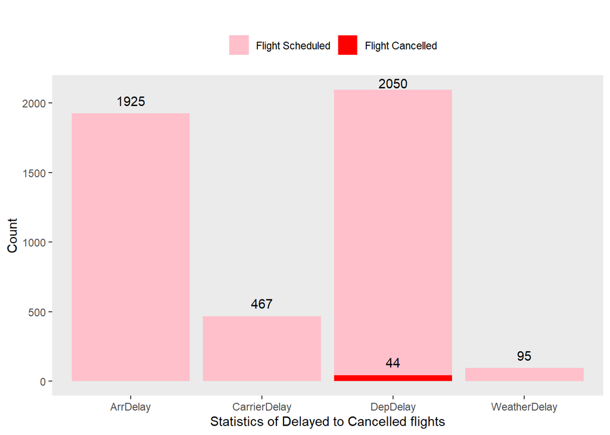

```r
ggplot(Cancelled, aes(Delay_Type, Count)) + geom_col(aes(fill = Cancelled ==1)) +
  geom_text(aes(Delay_Type, Count, label = Count),  vjust = -0.8) +
  theme(legend.position="top", panel.grid.major = element_blank(), panel.grid.minor = element_blank()) +
  labs(title = "",  x = "Statistics of Delayed to Cancelled flights",  y ="Count") +
  scale_fill_manual(name = " ", values = c('pink', 'red'), breaks = c("FALSE","TRUE"), label = c("Flight Scheduled", "Flight Cancelled"))
```

# 9. How many delayed flights were diverted? (approximation)

```r
Diverted <- FlightData %>% select("Diverted","ArrDelay","DepDelay","CarrierDelay","WeatherDelay") %>%
  gather("Delay_Type","Delay_Time",-1)%>%  filter(Delay_Time > 0) %>% group_by(Diverted,Delay_Type) %>% summarise(Count = n())

head(Diverted)
```

```
## # A tibble: 5 x 3
## # Groups:   Diverted [2]
##   Diverted Delay_Type   Count
##      <int> <chr>        <int>
## 1        0 ArrDelay      1925
## 2        0 CarrierDelay   467
## 3        0 DepDelay      2091
## 4        0 WeatherDelay    95
## 5        1 DepDelay         3
```

# Answer

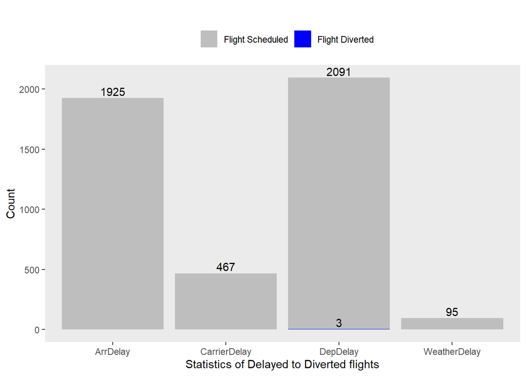

```r
ggplot(Diverted, aes(Delay_Type, Count)) + geom_col(aes(fill = Diverted == 1)) +
  geom_text(aes(Delay_Type, Count, label = Count),  vjust = -0.3) +
  theme(legend.position="top", panel.grid.major = element_blank(), panel.grid.minor = element_blank()) +
  labs(title = "",  x = "Statistics of Delayed to Diverted flights",  y ="Count") +
  scale_fill_manual(name = " ", values = c('grey', 'blue'), breaks = c("FALSE","TRUE"), label = c("Flight Scheduled", "Flight Diverted"))
```

# 10. What time of the day do you find Arrival delays?

```r
Arrival_DelayByTime <- FlightData  %>% filter(ArrDelay > 0)%>% select("ArrDelay","ArrTimeBlk") %>%
  group_by(ArrTimeBlk) %>% summarise(Count=n())

head(Arrival_DelayByTime)
```

```
## # A tibble: 6 x 2
##   ArrTimeBlk Count
##   <fct>      <int>
## 1 0001-0559     72
## 2 0600-0659     30
## 3 0700-0759     53
## 4 0800-0859     81
## 5 0900-0959     81
## 6 1000-1059     89
```

# Answer

- The data is filtered out in a way where we extract the count of arrival delay at particular time of the day.
- Thus the below graph can help us display a clear picture on what time of the day the arrival delay is prominent.
- To give a focus point for the management to take decisions I have highlighted the top Arrival delay timestamps.
- Thus we see that the maximum delay on arrival traffic is during the 8 to 10 PM whereas it is minimum during the late night and earlt mornings.

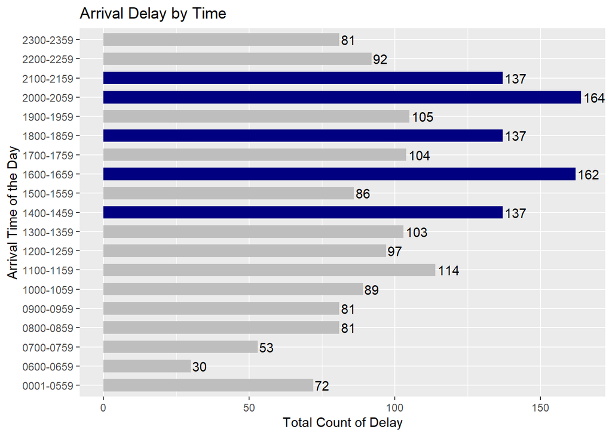

```r
ggplot(Arrival_DelayByTime, aes(ArrTimeBlk, Count)) +
  geom_col(aes(fill = Count > 125), width = 0.65) +
  scale_fill_manual(name = " ", values = c('grey', 'navy'))+
  geom_text(aes(ArrTimeBlk, Count, label = Count), hjust = -0.1) +
  theme(legend.position = "none") + coord_flip() +
  labs(title = "Arrival Delay by Time",  x = "Arrival Time of the Day",  y ="Total Count of Delay")
```

# 11. What time of the day do you find Departure delays?

```r
Departure_DelayByTime <- FlightData  %>% filter(DepDelay > 0)%>% select("DepDelay","DepTimeBlk") %>%
  group_by(DepTimeBlk) %>% summarise(Count=n())

head(Departure_DelayByTime)
```

```
## # A tibble: 6 x 2
##   DepTimeBlk Count
##   <fct>      <int>
## 1 0001-0559     74
## 2 0600-0659    160
## 3 0700-0759    149
## 4 0800-0859    126
## 5 0900-0959    144
## 6 1000-1059    146
```

# Answer

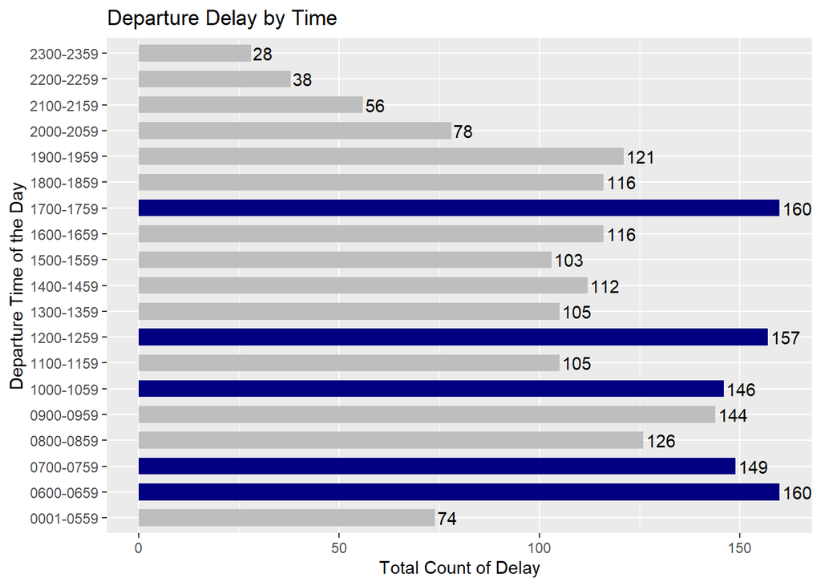

```r
ggplot(Departure_DelayByTime, aes(DepTimeBlk, Count)) +
  geom_col(aes(fill = Count > 145), width = 0.65) +
  scale_fill_manual(name = " ", values = c('grey', 'navy'))+
  geom_text(aes(DepTimeBlk, Count, label = Count), hjust = -0.1) +
  theme(legend.position = "none") + coord_flip() +
  labs(title = "Departure Delay by Time",  x = "Departure Time of the Day",  y ="Total Count of Delay")
```

# To conclude we can say that the arrival traffic and departure traffic takes place at the diffent time of the day.

# Clean data without any NA values.

```r
Clean_data <- FlightData[!sapply(FlightData, anyNA)]
dim(Clean_data)
```

```
## [1] 6934   54
```

```r
summary(Clean_data)
```

[output not shown]

[output cut: 73 more lines]

```
##  Min.   :1   Min.   :  31   Min.   : 1.000   Min.   :  0.000
##  1st Qu.:1   1st Qu.: 401   1st Qu.: 2.000   1st Qu.:  0.000
##  Median :1   Median : 794   Median : 4.000   Median :  0.000
##  Mean   :1   Mean   : 979   Mean   : 4.357   Mean   :  3.268
##  3rd Qu.:1   3rd Qu.:1400   3rd Qu.: 6.000   3rd Qu.:  0.000
##  Max.   :1   Max.   :4962   Max.   :11.000   Max.   :773.000
##
##  WeatherDelayMod    DivAirportLandings  Div1Airport    Div1TailNum   Duplicate
##  Min.   :  0.0000   Min.   :0.000000          :6919          :6927   N:6934
##  1st Qu.:  0.0000   1st Qu.:0.000000   LAX    :   3   N14235 :   1
##  Median :  0.0000   Median :0.000000   SEA    :   3   N16703 :   1
##  Mean   :  0.7877   Mean   :0.006778   OAK    :   2   N37267 :   1
##  3rd Qu.:  0.0000   3rd Qu.:0.000000   PDX    :   2   N622QX :   1
##  Max.   :850.0000   Max.   :9.000000   ABQ    :   1   N625QX :   1
##                                        (Other):   4   (Other):   2
```

# References

1. https://www.transtats.bts.gov/
2. Data Visualization: druhrao-ml-data–visualization-08242017_310311.pdf - by Professor Dr. Umesh R Hodeghatta
3. Data Visualization - ggplots.pdf - by Professor Dr. Umesh R Hodeghatta
4. https://www.datacamp.com/courses/data-visualization-with-ggplot2-1
5. https://www.datacamp.com/courses/data-visualization-with-ggplot2-2